# Example R notebook

# Loading packages

The very first thing that you would like to do is loading the required R libraries. Lets check whether you have successfully installed all the packages.

```r
library(tidyverse)
library(emmeans)
library(brms)
library(tidybayes)
library(bayestestR)
```

You will probably see some start message, and several warnings. If you don’t see any errors, then with 99% you are probably fine with this step.

# Obtaining the dataset.

Most of the datasets will be availabe through the course online repository (or some other repositories). Lets try to get the example dataset.

```r
library(foreign)
crime_data <- read.dta("https://stats.idre.ucla.edu/stat/data/crime.dta")
```

# Initial lookup at the data

There are several ways to look at the dataset. Lets try a simple `glimpse`.

```r
crime_data %>%
  glimpse()
```

```
Observations: 51
Variables: 9
$ sid      <dbl> 1, 2, 3, 4, 5, 6, 7, 8, 9, 10, 11, 12, 13, 14, 15, 16, 17, 18, 19, 20, 21, 22, 23, 24, 25…
$ state    <chr> "ak", "al", "ar", "az", "ca", "co", "ct", "de", "fl", "ga", "hi", "ia", "id", "il", "in",…
$ crime    <int> 761, 780, 593, 715, 1078, 567, 456, 686, 1206, 723, 261, 326, 282, 960, 489, 496, 463, 10…
$ murder   <dbl> 9.0, 11.6, 10.2, 8.6, 13.1, 5.8, 6.3, 5.0, 8.9, 11.4, 3.8, 2.3, 2.9, 11.4, 7.5, 6.4, 6.6,…
$ pctmetro <dbl> 41.8, 67.4, 44.7, 84.7, 96.7, 81.8, 95.7, 82.7, 93.0, 67.7, 74.7, 43.8, 30.0, 84.0, 71.6,…
$ pctwhite <dbl> 75.2, 73.5, 82.9, 88.6, 79.3, 92.5, 89.0, 79.4, 83.5, 70.8, 40.9, 96.6, 96.7, 81.0, 90.6,…
$ pcths    <dbl> 86.6, 66.9, 66.3, 78.7, 76.2, 84.4, 79.2, 77.5, 74.4, 70.9, 80.1, 80.1, 79.7, 76.2, 75.6,…
$ poverty  <dbl> 9.1, 17.4, 20.0, 15.4, 18.2, 9.9, 8.5, 10.2, 17.8, 13.5, 8.0, 10.3, 13.1, 13.6, 12.2, 13.…
$ single   <dbl> 14.3, 11.5, 10.7, 12.1, 12.5, 12.1, 10.1, 11.4, 10.6, 13.0, 9.1, 9.0, 9.5, 11.5, 10.8, 9.…
```

# Plotting some of the distributions.

We are interested in the crime level through states. Lets plot a simple histogram.

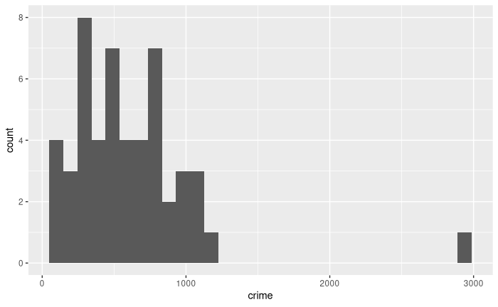

```r
crime_data %>%
  ggplot(aes(crime)) +
  geom_histogram()
```

The distribution looks fine appart from a single outlier. Lets plot one the predictors of crime - poverty.

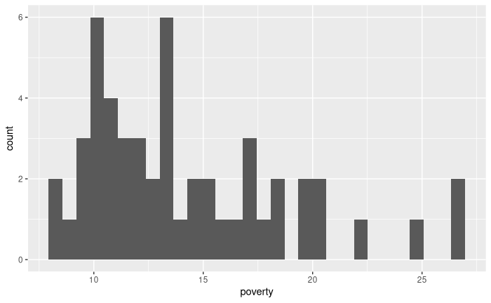

```r
crime_data %>%
  ggplot(aes(poverty)) +
  geom_histogram()
```

Now lets plot crime against poverty.

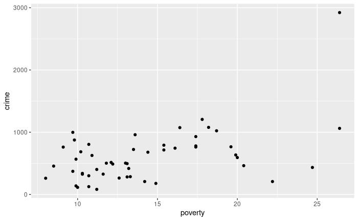

```r
crime_data %>%
  ggplot(aes(poverty, crime)) +
  geom_point()
```

# Creating a simple Bayesian regression model.

Lets fit crime against poverty. This is your `Hello world!` to Bayesian modelling. Don’t worry if you don’t understand what you are doing or what is happening. This just a quick intro to get you the feeling of how we will work through the course.

```r
fit <- brm(crime ~ poverty,
           data = crime_data,
           prior = prior(normal(0, 10), class = b))
```

# Summarising our results

Lets summarise our results.

```r
fit
```

```
 Family: gaussian
  Links: mu = identity; sigma = identity
Formula: crime ~ poverty
   Data: crime_data (Number of observations: 51)
Samples: 4 chains, each with iter = 2000; warmup = 1000; thin = 1;
         total post-warmup samples = 4000

Population-Level Effects:
          Estimate Est.Error l-95% CI u-95% CI Rhat Bulk_ESS Tail_ESS
Intercept   337.97    131.92    88.49   598.82 1.00     3621     3021
poverty      19.09      8.36     2.88    35.13 1.00     3527     3217

Family Specific Parameters:
      Estimate Est.Error l-95% CI u-95% CI Rhat Bulk_ESS Tail_ESS
sigma   410.36     43.16   334.84   501.89 1.00     3093     2724

Samples were drawn using sampling(NUTS). For each parameter, Eff.Sample
is a crude measure of effective sample size, and Rhat is the potential
scale reduction factor on split chains (at convergence, Rhat = 1).
```

It seems like poverty is positively and reliably associated with crime level (at the state level).

# Plotting our posterior.

Lets see to what extent the obtained posterior distribution supports positive association.

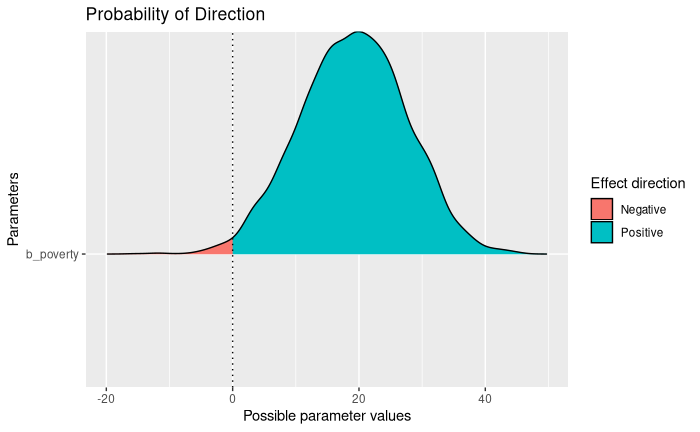

```r
pd_fit <- p_direction(fit)
plot(pd_fit)
```

# Plotting posterior against prior

Now lets compare posterior distribution to prior distribution.

```r
bf_fit <- bayesfactor_parameters(fit)
```

```
Computation of Bayes factors: sampling priors, please wait...
```

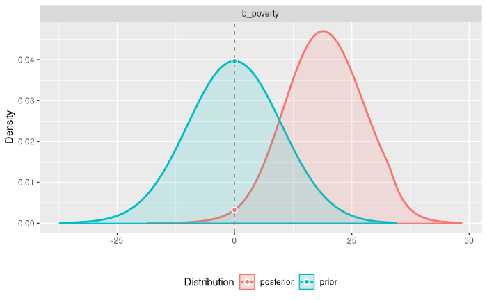

```r
plot(bf_fit)
```

# Plotting predictions against data

Now lets plot the fitted regression line against the collected data.

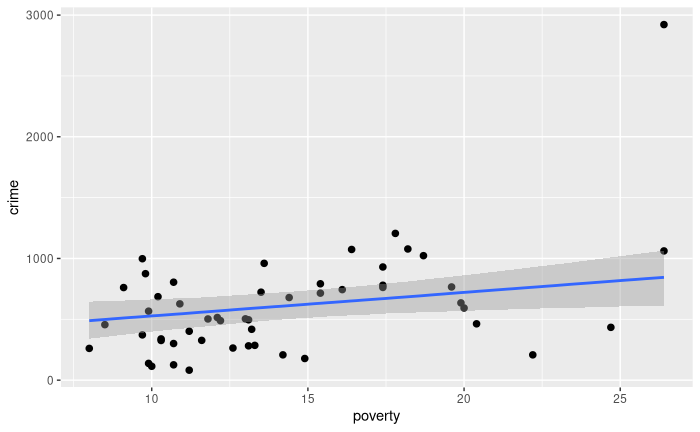

```r
marginal_effects(fit, effects = "poverty") %>%
  plot(points = T)
```

If you would like to fit predicted crime level given the poverty level it is also quite simple.

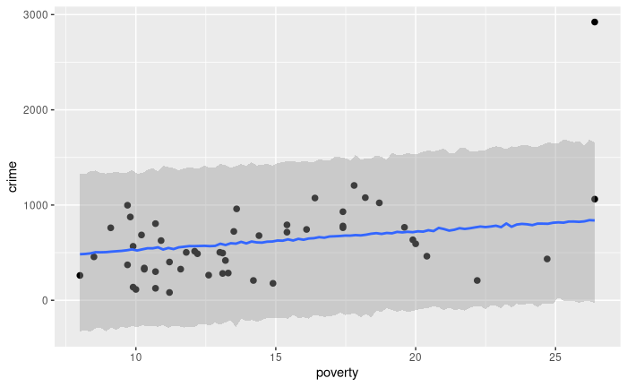

```r
marginal_effects(fit, effects = "poverty", method = "predict") %>%
  plot(points = T)
```

If you find the code in this notebook hard to follow, DON’T PANIC. It will get easier with time. I would also recommend you to go through some online tutorials. For example Hadley Wickham’s [R for Data Science](https://r4ds.had.co.nz/).